# Trabalho Modelagem Estátistica 1

Importando Libs para o trabalho prático

```r
library(zoo)
library(tseries)
library(data.table)
```

```r
library(ggplot2)
library(forecast)
library(gridExtra)
library(reshape2)
library(glmnet)
```

Lendo Arquivo csv com a lib ‘data.table’

```r
dataset = fread("dataset/day.csv", sep = ',')
```

```r
head(x = dataset, n=4)
```

| instant | dteday | season | yr | mnth | holiday | weekday | workingday | weathersit | temp | atemp | hum | windspeed | casual | registered | cnt |
| --- | --- | --- | --- | --- | --- | --- | --- | --- | --- | --- | --- | --- | --- | --- | --- |
| 1 | 01-01-2018 | 1 | 0 | 1 | 0 | 6 | 0 | 2 | 14.110847 | 18.18125 | 80.5833 | 10.74988 | 331 | 654 | 985 |
| 2 | 02-01-2018 | 1 | 0 | 1 | 0 | 0 | 0 | 2 | 14.902598 | 17.68695 | 69.6087 | 16.65211 | 131 | 670 | 801 |
| 3 | 03-01-2018 | 1 | 0 | 1 | 0 | 1 | 1 | 1 | 8.050924 | 9.47025 | 43.7273 | 16.63670 | 120 | 1229 | 1349 |
| 4 | 04-01-2018 | 1 | 0 | 1 | 0 | 2 | 1 | 1 | 8.200000 | 10.60610 | 59.0435 | 10.73983 | 108 | 1454 | 1562 |

Convertendo o atributo dteday para tipo date no R

```r
dataset[, dteday := as.Date(dteday,format = '%d-%m-%Y')]
```

## Analise de dados

Verificando a quantidade de instancias e colunas do conj. de dados

```r
data.frame(
    val = c(
        numero.de.colunas        = length(names(dataset)),
        quantidade.de.instancias = length(dataset$dteday)
    )
)
```

|  | val |
| --- | --- |
| numero.de.colunas | 16 |
| quantidade.de.instancias | 730 |

Verificando o tipo de cada atributo do conj. de dados, além disso, verificando se possui algum tipo de valor nulo.

```r
# Fazendo a verificação
result_ = dataset[ ,
    lapply(.SD,
            function(x){
                return(c(class(x), any(is.null(x))))
            }
        )
]
# Resultado transposto
df = transpose(result_, keep.names = 'col')

# Modificando os nomes de cada coluna
setnames(
    x = df,
    new = c('Atributos', 'Tipo do atributo', 'Possui valores nulos?')
)
```

```r
df
```

| Atributos | Tipo do atributo | Possui valores nulos? |
| --- | --- | --- |
| instant | integer | FALSE |
| dteday | Date | FALSE |
| season | integer | FALSE |
| yr | integer | FALSE |
| mnth | integer | FALSE |
| holiday | integer | FALSE |
| weekday | integer | FALSE |
| workingday | integer | FALSE |
| weathersit | integer | FALSE |
| temp | numeric | FALSE |

[output cut: 6 more lines]

> Maior parte dos atributos são do tipo númericos e inteiros, também, não possui valores nulos.

Pegandos as colunsa numericas,date, etc.

```r
numeros = df[ (`Tipo do atributo` == 'numeric') | (`Tipo do atributo` == 'integer') ]$Atributos
numeros
```

```
##  [1] "instant"    "season"     "yr"         "mnth"       "holiday"
##  [6] "weekday"    "workingday" "weathersit" "temp"       "atemp"
## [11] "hum"        "windspeed"  "casual"     "registered" "cnt"
```

Verificando a quantidade de valores unicos de cada atributo.

```r
# Resultado é transposto para melhor visualização
transpose(dataset[,
    lapply( .SD,
        function(x){
            return(c(uniqueN(x), class(x)))
        }
     )
], keep.names = "colunas")
```

| colunas | V1 | V2 |
| --- | --- | --- |
| instant | 730 | integer |
| dteday | 730 | Date |
| season | 4 | integer |
| yr | 2 | integer |
| mnth | 12 | integer |
| holiday | 2 | integer |
| weekday | 7 | integer |
| workingday | 2 | integer |
| weathersit | 3 | integer |
| temp | 498 | numeric |

[output cut: 6 more lines]

> - `Season`, `holiday`, `weekday`, `workingday`, `weathersit` são atributos catégoricos. e estão no tipo interger será passado para as.factor tanto para analise quanto para treinamento do modelo
> - `dteday` é atrubuto do tipo data e possui valores únicos com mesma quantidade de instancias.
> - `instant` é um chave primária pois os valores são únicos com mesma quantidade de instancias.
> - Demais atributos são númericos.

> **OBSERVAÇÃO** : como `instant` é único não será utilizado no modelo e nem será utilzada para demais analises estatisticas

Passando os dados categoricos para as.factor

```r
dataset[, season :=as.factor(season)]
dataset[, holiday:=as.factor(holiday)]
dataset[, weekday:=as.factor(weekday)]
dataset[, workingday:=as.factor(workingday)]
dataset[, weathersit:=as.factor(weathersit)]
```

Verificando média, variância, desvio padrão de cada atributo do dataset.

```r
describe = dataset[,
    lapply( .SD,
            function(x) return(
                list( as.numeric(mean(x)), max(x), min(x), sd(x), var(x))
                )
            ), .SDcols = names(dataset)[10:16]]

dt = transpose(describe, keep.names = c("colunas"),list.cols = TRUE)
setnames(
    dt, c("colunas", "média", 'max', "min", 'std', 'var')
)
```

```r
dt[ , lapply(.SD,
            function(x){
              if (class(x[1]) == 'character') return(x)
              return(round(as.numeric(x), 2))
            })]
```

| colunas | média | max | min | std | var |
| --- | --- | --- | --- | --- | --- |
| temp | 20.32 | 35.33 | 2.42 | 7.51 | 56.35 |
| atemp | 23.73 | 42.04 | 3.95 | 8.15 | 66.43 |
| hum | 62.77 | 97.25 | 0.00 | 14.24 | 202.71 |
| windspeed | 12.76 | 34.00 | 1.50 | 5.20 | 27.00 |
| casual | 849.25 | 3410.00 | 2.00 | 686.48 | 471254.62 |
| registered | 3658.76 | 6946.00 | 20.00 | 1559.76 | 2432847.29 |
| cnt | 4508.01 | 8714.00 | 22.00 | 1936.01 | 3748141.10 |

```r
849.25+3658.76
```

```
## [1] 4508.01
```

> A média de $cnt$ é a soma das médias de $casual$ com $registered$ é um fato interessante, mais há frente haverá uma análise dessas duas colunas com $cnt$

Verificando a densidade dos dados dos atributos númericos

```r
plots = lapply(numeros[9:15],
               function(col) {
                 ggplot(dataset, aes_string(x = col)) +
                   geom_histogram(aes(y = ..density..),bins = 30, fill = "#5c9ef6", color = "black") +
                   geom_density(color = "#FF0000", linewidth = 1, linetype = "dashed", adjust = 1) +
                   ggtitle(paste("Distribuição de", col))  +
                  theme_minimal()
})
# Exibindo o primeiro gráfico como exemplo
combined_plot <- do.call(grid.arrange, c(plots, ncol = 3))
```

[figure not shown]

Fazendo um teste de hipotese para verificar normalidade dos atributos

$$H₀: \text{Os dados seguem uma distribuição normal}. \\
H_1: \text{Os dados não seguem uma distribuição normal}$$

```r
print("Para um nivel de significancia de 0.05")
```

```
## [1] "Para um nivel de significancia de 0.05"
```

```r
lapply(numeros[9:15],
       function(x){
         value = shapiro.test(dataset[[x]])$p.value

         if ( value > 0.05) return(c("Aceito H0",x))
         else return(c("Rejeito H0 para ",x))

       })
```

```
## [[1]]
## [1] "Rejeito H0 para " "temp"
##
## [[2]]
## [1] "Rejeito H0 para " "atemp"
##
## [[3]]
## [1] "Rejeito H0 para " "hum"
##
## [[4]]
## [1] "Rejeito H0 para " "windspeed"
##
## [[5]]
## [1] "Rejeito H0 para " "casual"
##
## [[6]]
## [1] "Rejeito H0 para " "registered"
##
## [[7]]
## [1] "Rejeito H0 para " "cnt"
```

> Para um nivel de significancia de 0.05 para todos os atributos acima eu rejeito $H_0$

Verificando se há existencia de outilers no conj. dados

```r
numeros[9:15]
```

```
## [1] "temp"       "atemp"      "hum"        "windspeed"  "casual"
## [6] "registered" "cnt"
```

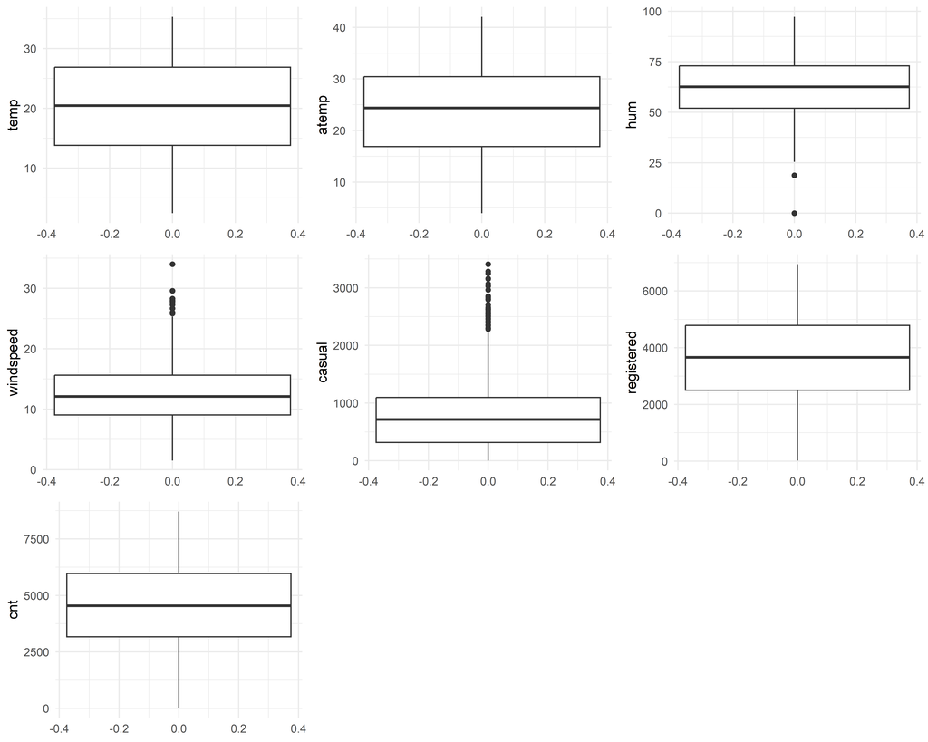

```r
plots  = lapply(
      numeros[9:15],
      function(col)
        {
        ggplot(dataset, aes_string(y = col)) +
          geom_boxplot() +
          theme_minimal()

      })
combined_plot <- do.call(grid.arrange, c(plots, ncol = 3))
```

> Os atributos **windspeed, casual e hum** possuem outliers. Não serão removidos esses outliers pois posa ser que essas colunas sejam removidas futuramente. Se não forem será mantido mesmo assim os outliers.

### Verificando a correlação entre target e as features

Modificando o atributo $dteday$ para o formato ano-mes para fazer posteriormente um agrupamento de alugueis totais de cada mes.

```r
dataset[, anoMes := format.Date(dataset$dteday, format = "%Y-%m")]
```

#### Verificando a série historica dos alugueis

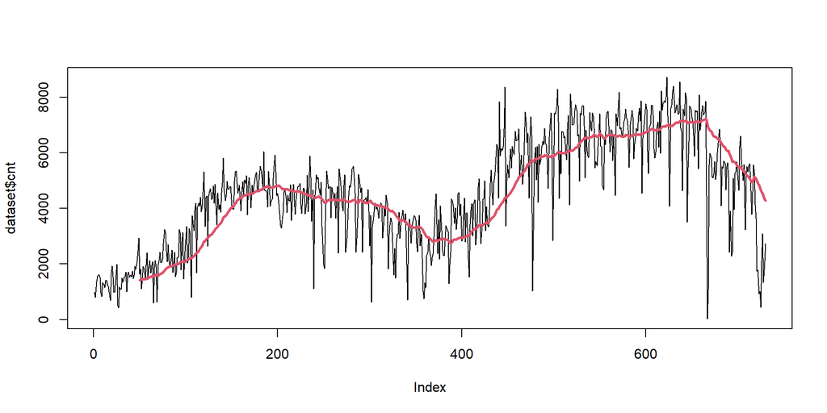

```r
X =  rollapply(dataset$cnt, width = 50, FUN = mean, align = "right", fill = NA)

plot(dataset$cnt, type = 'l', col=1, lwd=1)
lines(X, col=2, lwd = 3)
```

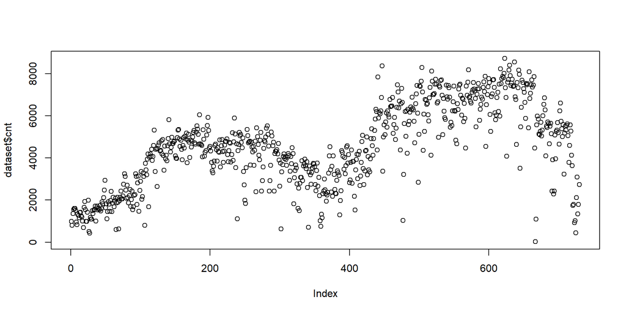

```r
X =  rollapply(dataset$cnt, width = 50, FUN = mean, align = "right", fill = NA)

plot(dataset$cnt, type = 'p', col=1, lwd=1, lty = 3)
```

#### Correlação entre alugueis e temperatura média em relação aos 10 ultimos pontos

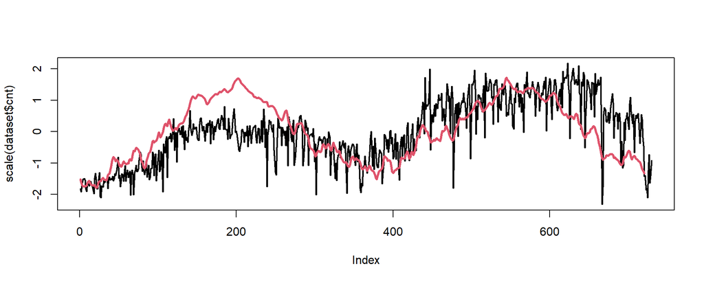

```r
roll = rollapply(scale(dataset$temp), FUN=mean, width=10, align='right')
plot(scale(dataset$cnt), type='l', lwd=2)
lines(roll, col=2, lwd=3, lty = 1)
```

> Esse método só permite identificar visualmente se existe um comportamento semelhante entre as variáveis ao longo do tempo. Contudo, podemos ver uma pequena relação entre essa variaveis

```r
cor(dataset$temp, dataset$cnt, method = 'kendall')
```

```
## [1] 0.431533
```

> Podemos ver uma no qual quando maior a temperatura maior será os alugueis.

#### Correlação entre alugueis e sensação de temperatura

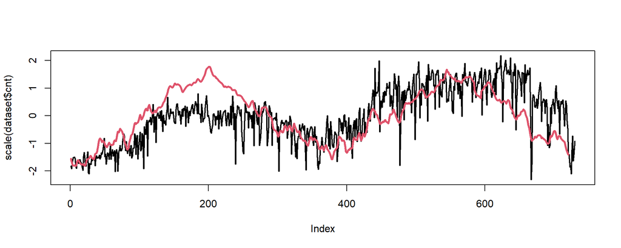

```r
roll = rollapply(scale(dataset$atemp), FUN=mean, width=10, align='right')
plot(scale(dataset$cnt), type='l', lwd=2)
lines(roll, col=2, lwd=3, lty = 1)
```

> Podemos ver o comportamento entre essas duas variáveis no decorrer do tempo assim como alugueis e temperatura média em relação aos 10 ultimos pontos.

```r
cor(dataset$temp, dataset$cnt, method = 'kendall')
```

```
## [1] 0.431533
```

Para treinamento do modelo será utilizado somente sensação termica($atemp$) e não a temperatura real($temp$), pois:

```r
cor(dataset$temp, dataset$atemp)
```

```
## [1] 0.9916962
```

Os atributos $temp$ e $atemp$ possuem uma correlação altissima e pode surgir um problema conhecido como **multicolinearidade.**

#### Possue alguma relação entre a diferenca de $temp$ e $atemp$ e a target ($cnt$)

```r
cor.test((dataset$temp-dataset$atemp), dataset$cnt, method = 'kendall')
```

```
##
##  Kendall's rank correlation tau
##
## data:  (dataset$temp - dataset$atemp) and dataset$cnt
## z = -13.848, p-value < 2.2e-16
## alternative hypothesis: true tau is not equal to 0
## sample estimates:
##        tau
## -0.3425459
```

#### Correlação da target($cnt$)e as demais features

```r
numeros = numeros[9:15]
```

```r
dtCor = round(cor(dataset[,..numeros], method='kendall'), 2)
dtCor = melt(dtCor)
```

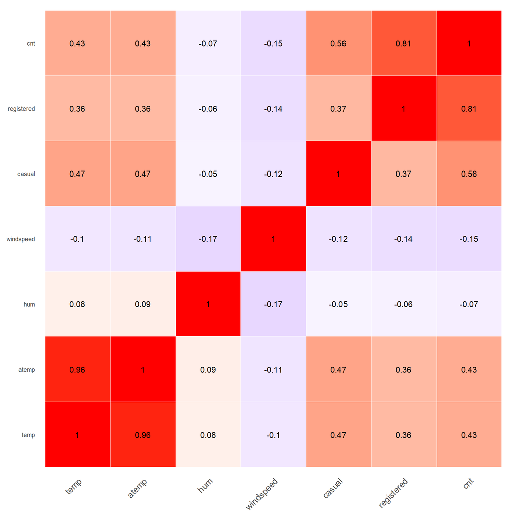

```r
ggheatmap <- ggplot(dtCor, aes(Var2, Var1, fill = value))+
 geom_tile(color = "white")+
 scale_fill_gradient2(low = "blue", high = "red", mid = "white",
   midpoint = 0, limit = c(-1,1), space = "Lab",
    name="Pearson\nCorrelation") +
  theme_minimal()+ # minimal theme
 theme(axis.text.x = element_text(angle = 45, vjust = 1,
    size = 12, hjust = 1))+
 coord_fixed()

ggheatmap +
geom_text(aes(Var2, Var1, label = value), color = "black", size = 4) +
theme(
  axis.title.x = element_blank(),
  axis.title.y = element_blank(),
  panel.grid.major = element_blank(),
  panel.border = element_blank(),
  panel.background = element_blank(),
  axis.ticks = element_blank(),
  legend.justification = c(1, 0),
  legend.position = c(1, 1),
  legend.direction = "horizontal")+
  guides(fill = guide_colorbar(barwidth = 7, barheight = 1,
                title.position = "top", title.hjust = 0.5))
```

> Será removido correlações baixo de 0.1 seguem abaixo as que serão removidas
> - hum

#### Casual e registered

```r
length(dataset$instant)
```

```
## [1] 730
```

```r
sum(( dataset$casual + dataset$registered) == (dataset$cnt))
```

```
## [1] 730
```

$cnt$ é a soma de $casual$ com $registered$ com isso não faz sentido utilizar para o modelo de regressão já que coloca um viés no modelo

## Ajustando modelo

Será leito novamente o conj. de dados

```r
data = fread("dataset/day.csv", sep = ',')
```

Removendo atributos que não serão utilizados para treinamento do modelo

```r
# removendo temp
data[, temp:=NULL]

# removendo dteday
data[, dteday:=NULL]

# removendo instant
data[, instant:=NULL]

data[, registered:=NULL]

data[, casual:=NULL]

data[, hum:=NULL]
```

Modificando o tipo para as.factor

```r
data[, season :=as.factor(season)]
data[, holiday:=as.factor(holiday)]
data[, weekday:=as.factor(weekday)]
data[, workingday:=as.factor(workingday)]
data[, weathersit:=as.factor(weathersit)]
data[, yr:=as.factor(yr)]
data[, mnth:=as.factor(mnth)]
```

```r
data
```

| season | yr | mnth | holiday | weekday | workingday | weathersit | atemp | windspeed | cnt |
| --- | --- | --- | --- | --- | --- | --- | --- | --- | --- |
| 1 | 0 | 1 | 0 | 6 | 0 | 2 | 18.181250 | 10.749882 | 985 |
| 1 | 0 | 1 | 0 | 0 | 0 | 2 | 17.686950 | 16.652113 | 801 |
| 1 | 0 | 1 | 0 | 1 | 1 | 1 | 9.470250 | 16.636703 | 1349 |
| 1 | 0 | 1 | 0 | 2 | 1 | 1 | 10.606100 | 10.739832 | 1562 |
| 1 | 0 | 1 | 0 | 3 | 1 | 1 | 11.463500 | 12.522300 | 1600 |
| 1 | 0 | 1 | 0 | 4 | 1 | 1 | 11.660450 | 6.000868 | 1606 |
| 1 | 0 | 1 | 0 | 5 | 1 | 2 | 10.441950 | 11.304642 | 1510 |
| 1 | 0 | 1 | 0 | 6 | 0 | 2 | 8.112700 | 17.875868 | 959 |
| 1 | 0 | 1 | 0 | 0 | 0 | 1 | 5.808750 | 24.250650 | 822 |
| 1 | 0 | 1 | 0 | 1 | 1 | 1 | 7.544400 | 14.958889 | 1321 |

[output cut: 720 more lines]

Utilizando o forward para encontrar o melhor modelo e parametros desse modelo

```r
# Criando modelo com somente o intercepto
modelInicial = lm(cnt ~ 1, data=data)

# Criando modelo com todas os atributos
modelCompleto = lm(cnt~., data = data)

# Selecionando o melhor modelo com stepwise
bestForward =  step(modelInicial,
                    scope=list(
                        lower=modelInicial,
                        upper=modelCompleto
                    ),
                    direction="forward")
```

```
## Start:  AIC=11050.84
## cnt ~ 1
##
##              Df  Sum of Sq        RSS   AIC
## + atemp       1 1086848335 1645546526 10683
## + mnth       11 1063738316 1668656545 10713
## + season      3  944051737 1788343124 10747
## + yr          1  886909480 1845485381 10766
## + weathersit  2  269371947 2463022914 10979
## + windspeed   1  151066708 2581328153 11011
## + holiday     1   12920003 2719474858 11049
## + workingday  1   10687682 2721707179 11050
## <none>                     2732394861 11051
## + weekday     6   17958746 2714436115 11058
##
## Step:  AIC=10682.65
## cnt ~ atemp
##
##              Df Sum of Sq        RSS   AIC
## + yr          1 798400233  847146293 10200
## + weathersit  2 162666940 1482879586 10611
## + season      3 152430786 1493115740 10618
## + mnth       11 133505174 1512041351 10643
## + windspeed   1  40158159 1605388367 10667
## + holiday     1   6338610 1639207916 10682
## <none>                    1645546526 10683
## + workingday  1   2328780 1643217746 10684
## + weekday     6  15518416 1630028110 10688
##
## Step:  AIC=10199.97
## cnt ~ atemp + yr
##
##              Df Sum of Sq       RSS   AIC
## + season      3 164789487 682356807 10048
## + mnth       11 152313486 694832807 10077
## + weathersit  2 120904291 726242003 10092
## + windspeed   1  39092408 808053885 10168
## + holiday     1   7803329 839342964 10195
## + weekday     6  16645729 830500565 10198
## + workingday  1   2823410 844322883 10200
```

[output cut: 43 more lines]

```
##
## Step:  AIC=9761.24
## cnt ~ atemp + yr + season + weathersit + mnth + windspeed + weekday
##
##              Df Sum of Sq       RSS    AIC
## + holiday     1   5533611 430564740 9753.9
## + workingday  1   5533611 430564740 9753.9
## <none>                    436098351 9761.2
##
## Step:  AIC=9753.92
## cnt ~ atemp + yr + season + weathersit + mnth + windspeed + weekday +
##     holiday
##
##        Df Sum of Sq       RSS    AIC
## <none>              430564740 9753.9
```

```r
#
summary(bestForward)
```

```
##
## Call:
## lm(formula = cnt ~ atemp + yr + season + weathersit + mnth +
##     windspeed + weekday + holiday, data = data)
##
## Residuals:
##     Min      1Q  Median      3Q     Max
## -4197.5  -374.5    62.7   486.8  2893.6
##
## Coefficients:
##              Estimate Std. Error t value Pr(>|t|)
## (Intercept)   600.947    182.319   3.296 0.001030 **
## atemp          81.304      8.447   9.625  < 2e-16 ***
## yr1          2078.551     58.433  35.571  < 2e-16 ***
## season2       834.811    182.400   4.577 5.58e-06 ***
## season3       855.493    216.677   3.948 8.66e-05 ***
## season4      1584.552    184.131   8.606  < 2e-16 ***
## weathersit2  -696.328     63.201 -11.018  < 2e-16 ***
## weathersit3 -2400.105    180.497 -13.297  < 2e-16 ***
## mnth2         212.945    146.593   1.453 0.146773
## mnth3         666.007    166.469   4.001 6.98e-05 ***
## mnth4         646.651    248.972   2.597 0.009593 **
## mnth5         920.368    266.767   3.450 0.000594 ***
## mnth6         897.389    273.981   3.275 0.001107 **
## mnth7         389.368    307.825   1.265 0.206326
## mnth8         749.736    296.179   2.531 0.011579 *
## mnth9        1143.587    264.225   4.328 1.72e-05 ***
## mnth10        579.632    244.615   2.370 0.018078 *
## mnth11       -102.242    234.699  -0.436 0.663239
## mnth12       -119.913    185.241  -0.647 0.517627
## windspeed     -31.301      5.934  -5.275 1.77e-07 ***
## weekday1      217.940    111.376   1.957 0.050768 .
## weekday2      333.045    108.897   3.058 0.002310 **
## weekday3      424.611    109.404   3.881 0.000114 ***
## weekday4      447.491    108.815   4.112 4.38e-05 ***
## weekday5      497.846    108.625   4.583 5.42e-06 ***
## weekday6      472.254    108.256   4.362 1.48e-05 ***
## holiday1     -549.844    182.926  -3.006 0.002743 **
## ---
## Signif. codes:  0 '***' 0.001 '**' 0.01 '*' 0.05 '.' 0.1 ' ' 1
##
## Residual standard error: 782.6 on 703 degrees of freedom
## Multiple R-squared:  0.8424, Adjusted R-squared:  0.8366
## F-statistic: 144.5 on 26 and 703 DF,  p-value: < 2.2e-16
```

Os parametros maior são estatisticacamente significativo para um nivel de significancia de 0.001

#### Interpretação dos coeficientes

1. **atemp :** Para cada aumento de 1 grau na sensação térmica, o número de bicicletas alugadas aumenta em aproximadamente 81, mantendo todas as outras variáveis constantes. Isso indica que dias com sensação térmica mais agradável tendem a aumentar a demanda por bicicletas.
2. **mnth :** dependendo da mes maior será o numero de alugueis, pois há meses em que o valor do coeficiente é maior.
3. **weekday :** dependedo do dia do mes maior será o número de alugueis
   - A mesma logica para weathersit e season
4. **windspeed :** Para cada aumento de 1 unidade na velocidade do vento, o número de bicicletas alugadas diminui em aproximadamente 31, mantendo todas as outras variáveis constantes. Ventos mais fortes desencorajam o uso de bicicletas.

```r
bestForward
```

```
##
## Call:
## lm(formula = cnt ~ atemp + yr + season + weathersit + mnth +
##     windspeed + weekday + holiday, data = data)
##
## Coefficients:
## (Intercept)        atemp          yr1      season2      season3      season4
##       600.9         81.3       2078.6        834.8        855.5       1584.6
## weathersit2  weathersit3        mnth2        mnth3        mnth4        mnth5
##      -696.3      -2400.1        212.9        666.0        646.7        920.4
##       mnth6        mnth7        mnth8        mnth9       mnth10       mnth11
##       897.4        389.4        749.7       1143.6        579.6       -102.2
##      mnth12    windspeed     weekday1     weekday2     weekday3     weekday4
##      -119.9        -31.3        217.9        333.0        424.6        447.5
##    weekday5     weekday6     holiday1
##       497.8        472.3       -549.8
```

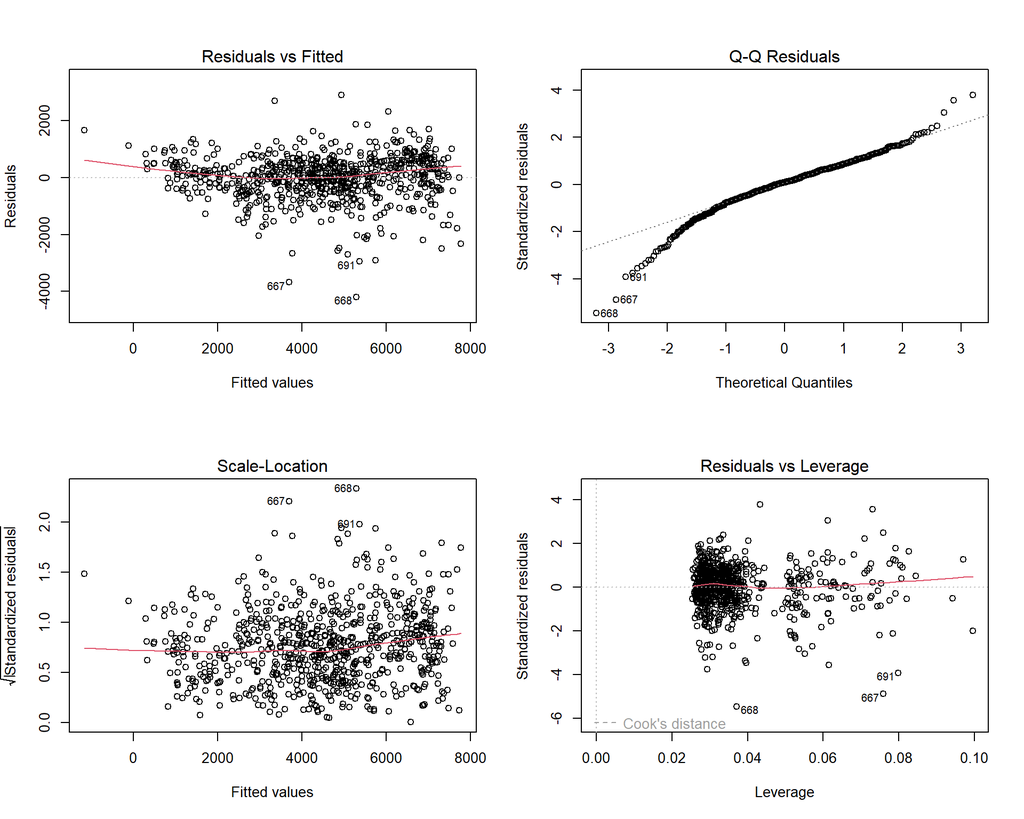

```r
par(mfrow=c(2, 2))
plot(bestForward)
```

```r
formula(bestForward)
```

```
## cnt ~ atemp + yr + season + weathersit + mnth + windspeed + weekday +
##     holiday
```

#### Comparando modelo proposto

$alugueis = β0 + β1 ·temperatura+ β2 ·vento+ β3 ·precipitacao+ β4 ·feriado+ ε$

```r
model.proposto = lm(cnt~atemp+windspeed+weathersit+workingday,data = data)

summary(model.proposto)
```

```
##
## Call:
## lm(formula = cnt ~ atemp + windspeed + weathersit + workingday,
##     data = data)
##
## Residuals:
##    Min     1Q Median     3Q    Max
##  -4136  -1018   -156   1094   4021
##
## Coefficients:
##              Estimate Std. Error t value Pr(>|t|)
## (Intercept)  1900.982    244.147   7.786 2.39e-14 ***
## atemp         138.022      6.592  20.939  < 2e-16 ***
## windspeed     -40.396     10.321  -3.914 9.94e-05 ***
## weathersit2  -607.991    112.413  -5.409 8.64e-08 ***
## weathersit3 -2426.293    318.261  -7.624 7.76e-14 ***
## workingday1   179.266    112.923   1.588    0.113
## ---
## Signif. codes:  0 '***' 0.001 '**' 0.01 '*' 0.05 '.' 0.1 ' ' 1
##
## Residual standard error: 1414 on 724 degrees of freedom
## Multiple R-squared:  0.4704, Adjusted R-squared:  0.4668
## F-statistic: 128.6 on 5 and 724 DF,  p-value: < 2.2e-16
```

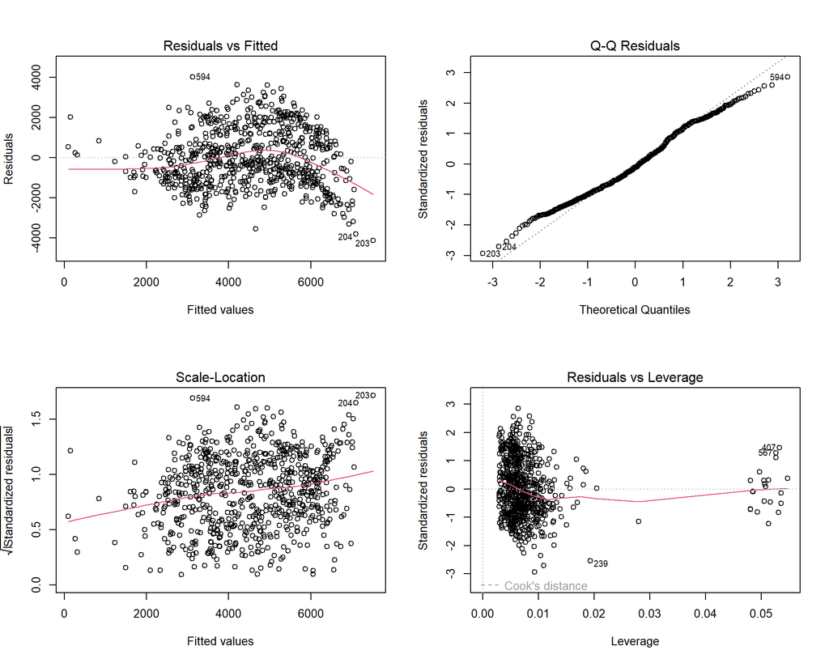

```r
par(mfrow=c(2, 2))
plot(model.proposto)
```

O modelo proposto apesar de ter maioria dos coeficiente estatistiticamente significativos com exclusão workingday. Modelos não desempenhou bons resultados, por exemplo, R2_score é ruim.

## Usando python para criação do modelo

Será feito o mesmo processo no R, com só a mundança na escolha de variaveis e modelos para treinar. Abaixo mostra as libs que serão utilizadas para essa etapa.

```python
import keras
import tensorflow as tf
import numpy as np
import pandas as pd
import matplotlib.pyplot as plt

from sklearn.model_selection import train_test_split, GridSearchCV
from sklearn.linear_model    import Ridge
from sklearn.ensemble        import ExtraTreesRegressor
from sklearn.feature_selection import RFE
from sklearn.preprocessing     import StandardScaler
```

Lendo o arquivo csv com o pandas

```python
data = pd.read_csv("dataset/day.csv", sep = ',')
print(data.head(3))
```

```
##    instant      dteday  season  yr  ...  windspeed  casual  registered   cnt
## 0        1  01-01-2018       1   0  ...  10.749882     331         654   985
## 1        2  02-01-2018       1   0  ...  16.652113     131         670   801
## 2        3  03-01-2018       1   0  ...  16.636703     120        1229  1349
##
## [3 rows x 16 columns]
```

Fazendo o dummies das colunas categoricas (no r foi as.factor)

```python
col = ["season","yr","mnth","holiday","weekday","workingday","weathersit"]

data = pd.get_dummies(data, columns=col, dtype=int)
```

```python
columns = data.drop(columns=['cnt', 'instant', 'dteday', 'temp', 'casual', 'registered', 'hum']).columns
```

Removendo as mesmas colunas que fiz usando R

```python
X = data.drop(columns=['cnt', 'instant', 'dteday', 'temp', 'casual', 'registered','hum']).values
y = data['cnt'].values.reshape(-1, 1)
```

```python
X.shape, y.shape
```

```
## ((730, 34), (730, 1))
```

### Dividindo treino e teste

```python
xtrain, xtest, ytrain, ytest = train_test_split(X, y, train_size=0.8,random_state=42)
```

```python
xtrain.shape[0], xtest.shape[0]
```

```
## (584, 146)
```

### Selecionando as features por meio $RFE$(Eliminação Recursiva de Características)

```python
# Usando florestas extra para seleção de caracterisitcas
extra = ExtraTreesRegressor(n_estimators=150, max_features='sqrt', random_state=42)

# Chamando a função RFE
rfe   = RFE(extra, n_features_to_select=10)

# treinando
col   = rfe.fit_transform(xtrain,ytrain.ravel())
```

```python
# As colunas que foram selecionadas foram...
columns[rfe.get_support()]
```

```
## Index(['atemp', 'windspeed', 'season_1', 'season_3', 'yr_0', 'yr_1', 'mnth_1',
##        'mnth_2', 'weathersit_1', 'weathersit_3'],
##       dtype='object')
```

> Essa foram as colunas escolhindas

Escalonando as variaveis numericas

```python
# Selecionando colunos para as caracteristicas e escalonando elas
Xtrain = StandardScaler().fit_transform(xtrain[:, rfe.get_support()])
Xtest  = StandardScaler().fit_transform(xtest[: ,rfe.get_support()])
```

Usando o modelo de Ridge e fazendo o gridsearch para escolha dos melhores hiperparametros

```python
grid = GridSearchCV(
    estimator = Ridge(),
    param_grid=dict(
      alpha=np.around(np.random.RandomState(seed=1).uniform(0.1,1,10),2),
      max_iter = np.arange(500, 1000, 200),
      solver  = ['cholesky', 'lsqr','sag']
    ),
  )
grid.fit(Xtrain, ytrain)
```

```
GridSearchCV(estimator=Ridge(),
             param_grid={'alpha': array([0.48, 0.75, 0.1 , 0.37, 0.23, 0.18, 0.27, 0.41, 0.46, 0.58]),
                         'max_iter': array([500, 700, 900]),
                         'solver': ['cholesky', 'lsqr', 'sag']})
```

Escolhendo os melhores hiperparametros do modelo Ridge

```python
grid.best_estimator_, grid.best_score_
```

```
## (Ridge(alpha=np.float64(0.75), max_iter=np.int64(500), solver='lsqr'), np.float64(0.7879950676269123))
```

```python
ridge = Ridge(alpha=np.float64(0.75), max_iter=np.int64(500), solver='lsqr')
ridge.fit(Xtrain, ytrain)
```

```
Ridge(alpha=np.float64(0.75), max_iter=np.int64(500), solver='lsqr')
```

Metricas para os dados de $train$

```python
predTrain = ridge.predict(Xtrain)
```

```python
r2 = keras.metrics.R2Score()
r2.update_state(predTrain, ytrain)

mse = keras.metrics.MeanSquaredError()
mse.update_state(predTrain, ytrain)

mae = keras.metrics.MeanAbsoluteError()
mae.update_state(predTrain, ytrain)


print(f"""
R2 Score................: {r2.result():.5f}
Error quadratico médio..: {mse.result():.5f}
Erro  médio absoluto....: {mae.result():.5f}
""")
```

```
##
## R2 Score................: 0.75609
## Error quadratico médio..: 747324.00000
## Erro  médio absoluto....: 639.07880
```

Fazendo validação cruzada para ver se as metricas são constante a cada iteração

```python
from sklearn.model_selection import ShuffleSplit

shuffle = ShuffleSplit(n_splits=12, test_size=0.25)

iter    = []
r2List  = []
mseList = []
for i,(train, test) in enumerate(shuffle.split(Xtrain)):
  iter.append(i)

  xtrain_, xtest_ = Xtrain[train,:], Xtrain[test, :]
  ytrain_, ytest_ = ytrain[train,:], ytrain[test, :]


  # treinando modelo
  ridge_ = Ridge(alpha=np.float64(0.8903056927518509), max_iter=np.int64(500), solver='lsqr')
  ridge_.fit(xtrain_, ytrain_)

  # predizendo
  pred_ = ridge_.predict(xtest_)

  r2 = keras.metrics.R2Score()
  r2.update_state(predTrain, ytrain)

  mse = keras.metrics.MeanSquaredError()
  mse.update_state(predTrain, ytrain)

  # Adicionando resultados
  r2List.append(r2.result())
  mseList.append(mse.result())
```

```
Ridge(alpha=np.float64(0.8903056927518509), max_iter=np.int64(500),
      solver='lsqr')
```

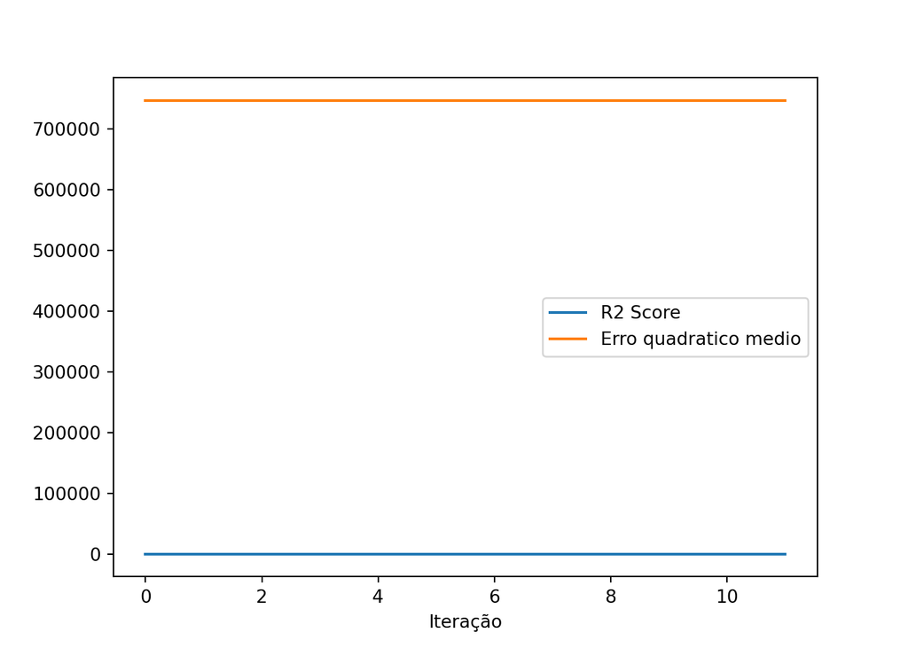

```python
plt.close()

plt.plot(r2List, label='R2 Score')
plt.plot(mseList, label='Erro quadratico medio')
plt.xlabel('Iteração')
plt.legend()
plt.show()
```

```python
pred = ridge.predict(Xtest)

r2 = keras.metrics.R2Score()
r2.update_state(predTrain, ytrain)

mse = keras.metrics.MeanSquaredError()
mse.update_state(predTrain, ytrain)

mae = keras.metrics.MeanAbsoluteError()
mae.update_state(predTrain, ytrain)


print(f"""
R2 Score................: {r2.result():.5f}
Error quadratico médio..: {mse.result():.5f}
Erro  médio absoluto....: {mae.result():.5f}
""")
```

```
##
## R2 Score................: 0.75609
## Error quadratico médio..: 747324.00000
## Erro  médio absoluto....: 639.07880
```

Poderia ser utilizado outros modelos que poderiam apresentar um resultado melhor do que no R como redes neurais, xboost-gradient, métodos ensemble. Preferi utilizar Ridge que foi ensinado em sala de aula e se encaixa com a tema da caderia.

## Conclusão

```r
summary(bestForward)
```

```
##
## Call:
## lm(formula = cnt ~ atemp + yr + season + weathersit + mnth +
##     windspeed + weekday + holiday, data = data)
##
## Residuals:
##     Min      1Q  Median      3Q     Max
## -4197.5  -374.5    62.7   486.8  2893.6
##
## Coefficients:
##              Estimate Std. Error t value Pr(>|t|)
## (Intercept)   600.947    182.319   3.296 0.001030 **
## atemp          81.304      8.447   9.625  < 2e-16 ***
## yr1          2078.551     58.433  35.571  < 2e-16 ***
## season2       834.811    182.400   4.577 5.58e-06 ***
## season3       855.493    216.677   3.948 8.66e-05 ***
## season4      1584.552    184.131   8.606  < 2e-16 ***
## weathersit2  -696.328     63.201 -11.018  < 2e-16 ***
## weathersit3 -2400.105    180.497 -13.297  < 2e-16 ***
## mnth2         212.945    146.593   1.453 0.146773
## mnth3         666.007    166.469   4.001 6.98e-05 ***
## mnth4         646.651    248.972   2.597 0.009593 **
## mnth5         920.368    266.767   3.450 0.000594 ***
## mnth6         897.389    273.981   3.275 0.001107 **
## mnth7         389.368    307.825   1.265 0.206326
## mnth8         749.736    296.179   2.531 0.011579 *
## mnth9        1143.587    264.225   4.328 1.72e-05 ***
## mnth10        579.632    244.615   2.370 0.018078 *
## mnth11       -102.242    234.699  -0.436 0.663239
## mnth12       -119.913    185.241  -0.647 0.517627
## windspeed     -31.301      5.934  -5.275 1.77e-07 ***
## weekday1      217.940    111.376   1.957 0.050768 .
## weekday2      333.045    108.897   3.058 0.002310 **
## weekday3      424.611    109.404   3.881 0.000114 ***
## weekday4      447.491    108.815   4.112 4.38e-05 ***
## weekday5      497.846    108.625   4.583 5.42e-06 ***
## weekday6      472.254    108.256   4.362 1.48e-05 ***
## holiday1     -549.844    182.926  -3.006 0.002743 **
## ---
## Signif. codes:  0 '***' 0.001 '**' 0.01 '*' 0.05 '.' 0.1 ' ' 1
##
## Residual standard error: 782.6 on 703 degrees of freedom
## Multiple R-squared:  0.8424, Adjusted R-squared:  0.8366
## F-statistic: 144.5 on 26 and 703 DF,  p-value: < 2.2e-16
```

É o modelo escolhido pois desempenhou bons resultados.

```r
formula(bestForward)
```

```
## cnt ~ atemp + yr + season + weathersit + mnth + windspeed + weekday +
##     holiday
```